# Linear algebra

Weiquan Luo

2022-07-18

# Table of Contents

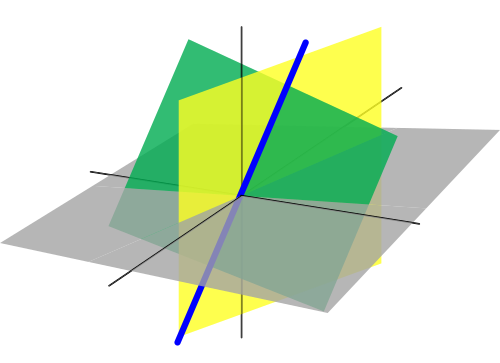

# Introduction

Linear algebra usually work on three subjects: Scalar, Vector, and Matrix. They occupy on different Mathmetical space. So the algebra of the three subjects has different properties.

[figure not shown]

| subjects | Mathmetical space | Common definition in linear algebra |
| --- | --- | --- |
| Scalar (0d-array) | field $\mathbb{F}$ | usually real numbers $\mathbb{R}$ (contains $\mathbb{Q}$, $\mathbb{Z}$, $\mathbb{N}$), complex number $\mathbb{C}$ |
| Vector (1d-array) | vector space over a field, $\mathbb{V}$ | usually real vector space $\mathbb{R}^n$ or complex vector space $\mathbb{C}^n$ |
| Matrix (2d-array) | vector space of functions | linear (Bijective) mapping $f: V \to W$ |
| Tensor (nd-array) | N/A | N/A |

Hint:

- Avoid using `np.dot`, because its reactions vary by dimentions of the input array. Instead, using specifialized functions such as:
  - `np.inner()` for inner product 1darray
  - `np.matmul()` for matrix multiplication of 2darray and ndarray

# Scalar: Field

In mathematics, a field is a set on which addition, subtraction, multiplication, and division are defined and behave as the corresponding operations on rational and real numbers do. A field is thus a fundamental algebraic structure which is widely used in algebra, number theory, and many other areas of mathematics. (Cite: wiki))

In real number field $\mathbb{R}$:

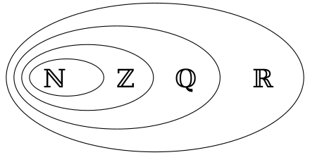

| Algebra | Mathematical expression | python operation |
| --- | --- | --- |
| **Addition** | $a + b$ | `a+b` |
| :: commutative property | $a+b$ $=b+a$ |  |
| :: associative property | $(a+b)+c$ $=a+(b+c)$ |  |
| **Subtraction** | $a - b$ | `a/b` |
| :: Ordered property | $a \geq b$ $a + c \geq b + c$ | `a>b`, `a>=b` `a>b`, `a<=b` `a==b` `a!=b` |
| **Multiplication** | $a \times b$ | `a*b` |
| :: commutative property | $a \times b$ $=b \times a$ |  |
| :: associative property | $(a \times b) \times c$ $=a \times (b \times c)$ |  |
| :: distributive property | $c \times (a+b)$ $=c \times a + c \times b$ |  |
| :: exponentiation | $a^b$ | `a**b` |
| :: root (even root only for Non-nagative) | $ \sqrt[b]{a}$ | `a**(1/b)` |
| **Division** | $\frac{a}{b}$ | `a/b` |
| :: Modulus (reminder) | - | `a%b` |
| :: Floor division (rounded division) | - | `a//b` |

# Vector: Vector spaces

A point in a coordinate system can be represented by a vector:

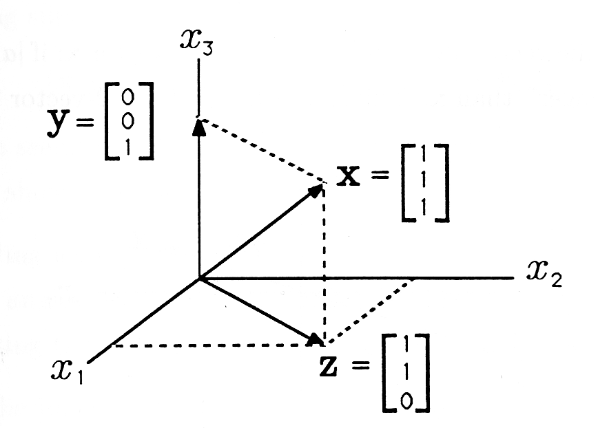

Usually, the vector space is over the real number field $\mathbb{R}$, then it forms a Euclidean space. Euclidean space is a normed, completed vector space.

| Algebra | Mathematical expression | Numpy operation |
| --- | --- | --- |
| **Scalar** |  |  |
| ::Element-wise addition | $\vec{a} + \vec{b}$ | `a+b` `np.add(a,b)` |
| ::Element-wise subtraction | $\vec{a} - \vec{b}$ | `a/b` `np.subtract(a,b)` |
| ::Element-wise multiplication (Hamandard product) | $\langle \vec{a}, \vec{b} \rangle_{ham}$ | `a*b` `np.multiply(a,b)` |
| ::Element-wise division | $\langle \vec{a}, \vec{b}\rangle_{div}$ | `a/b` `np.divide(a,b)` |
| **Vector** |  |  |
| ::Frobenius norm/L2-norm (length) | $\lvert \vec{a} \rvert$ | `np.linalg.norm(a)`) |
| ::Inner product (similarity) | $\vec{a} \cdot \vec{b}$ | `np.inner(a,b)` `np.dot(a,b)` (not recommanded) |
| ::Cross product (normal vector) | $\vec{a} \times \vec{b}$ | `np.cross(a,b)` |

# Matrix: Vector spaces of functions

A linear equations system can be rewrote into matrix form:

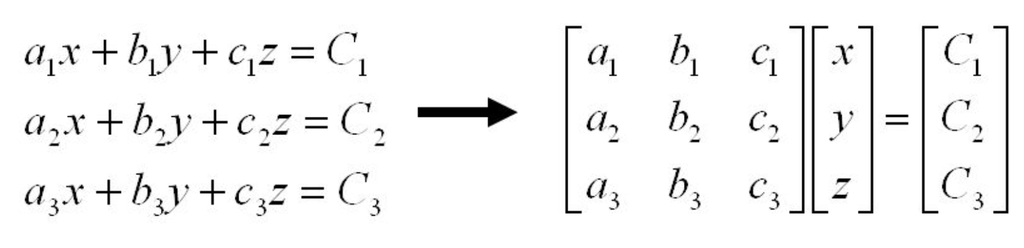

The coefficient matrix is also called linear mapping, denote as $f: V \to W$, which also defines the change of basis. This coefficient matrix is within the Vector spaces of functions, whose properties are different from that of Vector spaces over a real number field.

- It is no longer necessarily a normed vector space, so *lengths* or *angles* might not be defined.
- As the most important property of linear mapping, the **determinate** is defined to describe the changing ratio of area/volume due to the linear mapping.
- The **eigenvectors** of the transformation are also defined to describe the vector that staying on thier original direction.
- Then, the **eigenvalues** further describe the factor of streching/squashed of the lenght of these Eigenvectors.

| Algebra | Mathematical expression | Numpy operation |
| --- | --- | --- |
| **Scalar** (Element-wise) |  |  |
| ::Element-wise addition | $A + B$ | `A+B` `np.add(A,B)` |
| ::Element-wise subtraction | $A - B$ | `A/B` `np.subtract(A,B)` |
| ::Element-wise multiplication (Hamandard product) | $\langle A, B \rangle_{ham}$ | `A*B` `np.multiply(A,B)` |
| ::Element-wise division | $\langle A, B\rangle_{div}$ | `A/B` `np.divide(A,B)` |
| **Vector** |  |  |
| ::Frobenius inner product (similarity) | $\langle A,B\rangle_F$ | `(A*B).sum()` `np.multiply(A,B).sum()` |
| ::Row-wise inner product |  | `np.inner(A, B)`) |
| **Matrix** |  |  |
| Matrix multiplication product (transformation, mapping) | $AB$ $A \cdot B$ | `np.matmul(A, B)` `np.dot(A,B)` (not recommanded) |
| ::Determinant | $\lvert A \rvert$ | `np.linalg.det(A)`) |
| ::Transpose | $(A_{ij})^{T} = A_{ji}$ | `A.T` `A.transpose()` |
| ::No commutative exception A is Invertible/Nonsingular | $AB \neq BA$ |  |
| ::associative | $(AB)C=A(BC)$ |  |
| ::Distributive | $C(A+B)$ $=CA +CA$ |  |
| ::Uniqueness of inverse | $B = A^{-1}$ $(A^{-1})^{-1} = A$ |  |

## Special matrices

Special matrices

example

Some unique property

identity matrix

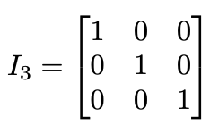

diagonal matrix

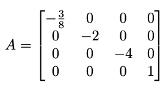

upper/lower-triangular matrix

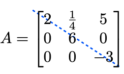

symmetric matrix

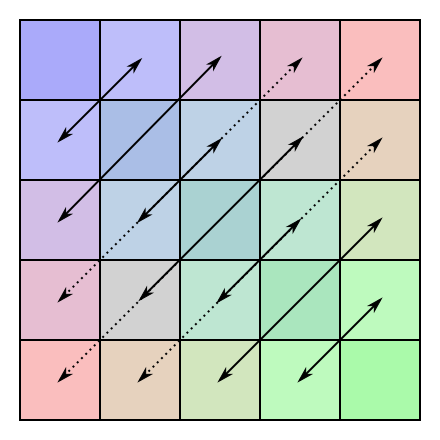

$A = A^T$

zero matrix

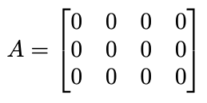

positive-definite matrix

all eigenvalue are positive

orthogonal matrix

$A^{T}= A^{-1}$  
$AA^{T} = A^{T}A = I$  
$det(A)=\pm1$

invertable/Nonsingular matrix

$AB=BA=I$

determinate of trianglal matrix is produce of diagnoal

$det(U) = \prod_{i=1}^{n} u_{ii}$

# Tensor:

Tensor is not tipically appear in the context of linear algebra. Instead, it is the typical form of storing 2d/3d/4d raster data such as images.

- Because it is no longer within any vector space of field or function, so it does not have any proerty relative to *normed* (length, angle, similarity) or *mapping* (eigenvector, eigenvalue).
- It represents the actual value at each location in a Cartesian coordinate system $\mathbb{R^3}$ or euclidean space $\mathbb{R^n}$. In most of the time, the most interesting things are the **spatial information** such as distribution, gradient and the isosurface of these value.

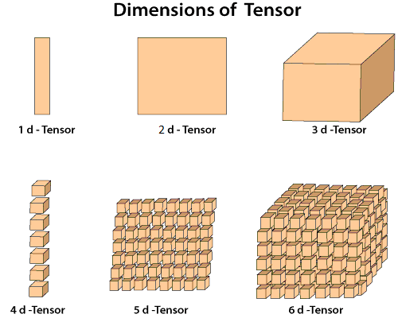

## Einstein summation convention

| Description | Numpy function | Call signature in `np.einsum` |
| --- | --- | --- |
| Return A | A | (‘i’, A) |
| Summation | np.sum(A) | (‘i->’, A) |
| Element-wise multiplication | A * B | (‘i,i->i’, A, B) |
| Inner product | np.inner(A, B) | (‘i,i’, A, B) |
| Outer(cross) product | np.outer(A, B) | (‘i,j->ij’, A, B) |

| Description | Numpy function | Call signature in `np.einsum` |
| --- | --- | --- |
| Return A | A | (‘ij’, A) |
| Transpose | A.T | (‘ji’, A) |
| Diagonal | np.diag(A) | (‘ii->i’, A) |
| Summation over diagonal | np.trace(A) | (‘ii’, A) |
| Summation | np.sum(A) | (‘ij->’, A) |
| Summation over col | np.sum(A, axis=0) | (‘ij->j’, A) |
| Summation over row | np.sum(A, axis=1) | (‘ij->i’, A) |
| Element-wise multiplication of A and B | A * B | (‘ij,ij->ij’, A, B) |
| Element-wise multiplication of A and B.T | A * B.T | (‘ij,ji->ij’, A, B) |
| matrix multiplication | np.matmul(A, B) | (‘ij,jk’, A, B) |
| matrix-vector multiplication, finite or infinite dimensional field, $\mathbb{K}$ | np.inner(A,B) | (‘ij,jk’, A, B) |
| matrix-matrix multiplication, $\mathbb{R}^n$ | np.dot(A,A.T) | (‘ij,jk’, A, B) |
| Inner product | np.inner(A, B) | (‘ij,kj->ik’, A, B) |
| A的每一行乘以B | A[:, None] * B | (‘ij,kj->ijk’, A, B) |
| A的每个值乘以B | A[:, :, None, None] * B | (‘ij,kl->ijkl’, A, B) |

```python
!python3 -m jupyter nbconvert jupyter_LinearAlgebra.ipynb --to html
```

```
[NbConvertApp] Converting notebook jupyter_LinearAlgebra.ipynb to html
[NbConvertApp] Writing 595405 bytes to jupyter_LinearAlgebra.html
```